# RMarkdownDemo

liang kuang

2017-04-25

# 1 Load the packages

```r
suppressPackageStartupMessages({
library(knitr)
library(pander)
library(dygraphs)
library(zoo)
library(Quandl)
library(ggplot2)
})
```

# 2 R Markdown Layout

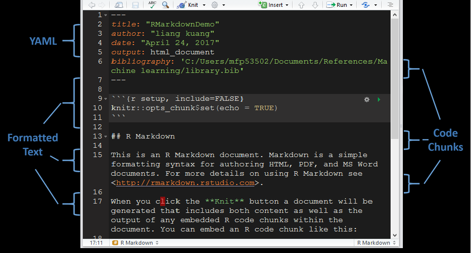

# 3 Global settings

Before writing your RMarkdown document, user can specify the global settings for the global environment. For example, setting whether to echo your R code and show the code/results etc. in the document. You can either set the options globally or for individual code blocks.

```
## global setting for all blocks

{r setup, include = FALSE}
knitr::opts_chunk$set(echo = TRUE)

## setting for individual code block

{r chuck_name, echo = FALSE, results = "hide", include = TRUE}
x <- rnorm(100)
y <- 2*x + rnorm(100)
```

If you want all the figures take the same amount of space, use the following commands:

```
{r global_options, include = FALSE}
knitr::opts_chunk$set(fig.width = 12, fig.height = 8, fig.path = 'Figs/',
                      echo = FALSE, warning = FALSE, message = FALSE)
# While setting figure path, the '/' is very import.
```

Also, you can individually change the settings for your figure windows. This will overwrite global settings. This is very convenient especially when you have images for different data size. For example, by specifying ‘fig.with’ and ‘fig.height’:

```
{r scatterplot, fig.width = 8, fig.height = 6}
plot(x,y)
```

# 4 Create Paragraphs With Styles

## 4.1 Headers

```
# Header 1
## Header 2
### Header 3
```

## 4.2 Lists

### 4.2.1 Unordered List

```
* Item 1
* Item 2
    + Item 2a
    + Item 2b
```

This is the example output for Unordered Lists:

- Item 1
- ITem 2
  - Item 2a
  - Item 2b

### 4.2.2 Ordered List

```
1. Item 1
2. Item 2
3. Item 3
    + Item 3a
    + Item 3b
```

This is the example output for ordered list:

1. Item 1
2. Item 2
3. Item 3
   - Item 3a
   - Item 3b

## 4.3 Emphasis

From time to time, we might want to emphasize our text either using `{**bold**}` or `{*italic*}`. Also, we can change the text color by using styles. We can say roses are red, violets are blue by using command `<span style="color:red">red</span>` and `<span style="color:blue">blue</span> repsectively.`

# 5 Embed code chunk, inline code and run R code

## 5.1 R Code Chunks

R code will be evaluated and printed

```r
size = 750
x = as.data.frame(matrix(runif(14*size),ncol=14))
head(x)
```

```
##           V1        V2        V3        V4         V5         V6
## 1 0.02501702 0.9335703 0.2098806 0.9169109 0.09329630 0.39390823
## 2 0.20245720 0.4284618 0.4415630 0.1920151 0.72756080 0.02446245
## 3 0.41308319 0.9710235 0.9897902 0.9453294 0.21324447 0.95279089
## 4 0.21106035 0.3452059 0.2114051 0.6180024 0.97044844 0.69796932
## 5 0.80157555 0.3224857 0.2789693 0.8656510 0.07174785 0.90185309
## 6 0.75464299 0.5663123 0.4422119 0.8693234 0.21348089 0.54622555
##           V7         V8         V9       V10        V11       V12
## 1 0.63041270 0.19350726 0.77258057 0.7930736 0.36268982 0.3358911
## 2 0.79352252 0.95072784 0.77479265 0.1912723 0.28115329 0.5723912
## 3 0.09613961 0.42858790 0.56875783 0.4090673 0.33272029 0.3131512
## 4 0.78938845 0.80889497 0.93003123 0.5519659 0.06732099 0.9545012
## 5 0.76625286 0.42432399 0.32786424 0.9632891 0.56926756 0.8270779
## 6 0.41956000 0.09838115 0.06640651 0.8383682 0.65092725 0.8883097
##         V13       V14
## 1 0.5179090 0.7651570
## 2 0.6087272 0.4102173
## 3 0.4020614 0.6969509
## 4 0.5243823 0.9298404
## 5 0.8577877 0.8070880
## 6 0.8391916 0.2548712
```

```
x = matrix(runif(14*size),ncol=14)
y = 10 * sin(pi*x[,1]*x[,2]) + 20*(x[,3]-0.5)**2 + 10*x[,4] + 5*x[,5] + runif(1,0,1)
x[,11:14] = x[,1:4] + matrix(runif(4*size,min = 0, max = 0.025),ncol=4)
```